# Problem Set 07

Your Name Goes Here

Last compiled: August 20, 2023 at 10:24:07 AM

# 1 Background

For this exercise, we will mimic the tactile sampling you did in class with virtual sampling. We will use some data from the [general social survey](http://gss.norc.org/), an annual personal-interview survey conducted in the United States. The survey is designed to monitor changes in both social characteristics and attitudes.

The **population** of interest will be **ALL** 2538 individuals living in a single neighborhood in 2014. As an analogy to the tactile sampling you did in class, the neighborhood is the “bowl” and the 2,538 people are the little balls.

If you get stuck as you are working through this Problem Set, we **strongly recommend** you re-read Chapter 7 in ModernDive, in particular subsections 7.3.1 on “Terminology & notation” and 7.3.2 on “Statistical definitions”. These terminology, notation, and definitions related to sampling are definitely tricky at first; the best method to master them is practice, practice, practice.

### Key points on symbols:

| Symbol | POPULATION PARAMETER | SAMPLE STATISTIC |
| --- | --- | --- |
| Number of cases | $N$ | $n$ |
| Proportion | $p$ | $\hat{p}$ |
| Standard error | $SE$ | $\widehat{SE}$ |

## Setup

First load the necessary packages:

```r
library(ggplot2)
library(dplyr)
library(forcats)
library(moderndive)
```

You can load and and view the `gss_cat` data set from the `forcats` package using the code below:

```r
data(gss_cat)
glimpse(gss_cat)
```

```
Rows: 21,483
Columns: 9
$ year    <int> 2000, 2000, 2000, 2000, 2000, 2000, 2000, 2000, 2000, 2000, 20…
$ marital <fct> Never married, Divorced, Widowed, Never married, Divorced, Mar…
$ age     <int> 26, 48, 67, 39, 25, 25, 36, 44, 44, 47, 53, 52, 52, 51, 52, 40…
$ race    <fct> White, White, White, White, White, White, White, White, White,…
$ rincome <fct> $8000 to 9999, $8000 to 9999, Not applicable, Not applicable, …
$ partyid <fct> "Ind,near rep", "Not str republican", "Independent", "Ind,near…
$ relig   <fct> Protestant, Protestant, Protestant, Orthodox-christian, None, …
$ denom   <fct> "Southern baptist", "Baptist-dk which", "No denomination", "No…
$ tvhours <int> 12, NA, 2, 4, 1, NA, 3, NA, 0, 3, 2, NA, 1, NA, 1, 7, NA, 3, 3…
```

Be sure to examine the data in the **viewer**. Type `?gss_cat` in the **console** to see a description of the variables in this data set.

# 2 Exploratory Data Wrangling

This data set includes many of years of data and many variables. To start, we will restrict our analysis to only 2014, and to only the variable indicating the `marital` status of each respondent.

```r
gss_14 <- gss_cat %>%
  filter(year == 2014) %>%
  select(marital)
```

The following shows the different responses for `marital` status:

```r
gss_14  %>%
  distinct(marital)
```

| marital |
| --- |
| Divorced |
| Married |
| Never married |
| Separated |
| Widowed |
| No answer |

## Setting a Seed

**Setting a seed:** We will take some random samples in this Problem Set. In order to make sure R takes the same random sample every time you run your code, you can do what is called “setting a seed”. Do this in any code chunk where you take a random sample.

You can set a seed with any number.

```r
set.seed(45)
```

# 3 The True Population Proportion $p$ of Divorced People

Again, for this exercise, the **population** of interest will be **ALL** 2538 individuals living in this single neighborhood in 2014. Since we have data on **ALL** 2538 people living in the neighborhood, we can compute the **exact population proportion $p$ of divorced people directly** using **ALL** the data as follows:

```r
gss_14 %>%
  summarize(divorced = sum(marital == "Divorced"),
            N = n(),
            p1 = mean(marital == "Divorced")) %>%
  mutate(p = divorced / N) -> ans
ans
```

| divorced | N | p1 | p |
| --- | --- | --- | --- |
| 411 | 2538 | 0.1619385 | 0.1619385 |

> Note that we use $N$ for the size of the full population of 2538 people, and $p$ because we are calculating the TRUE population proportion $p$.

> Note that no inference to the population is needed. We do not need to use a **sample** to try to infer something about the **true population proportion $p$** of divorced people in this neighborhood in 2014. We know that $p = 0.1619385$.

In other words, this problem set is not a realistic reflection of a real life problem. However, for this problem set, we are *simulating* the act of sampling from this neighborhood population to understand and study how factors like sample size influence **sampling variation**.

# 4 Demo: Sampling 50 People in the Neighborhood

## 4.1 Estimating $\hat{p}$ from a Single Sample

We are first going to use random sampling to **ESTIMATE** the true **population** proportion $p$ of the neighborhood that are divorced with only a **sample** of 50 people.

> This will represent a situation of only having the resources to knock on 50 doors to get responses from people in this neighborhood!

Be sure to look at the results in the viewer. Remember, you can set the seed to whatever value you like. For this exercise, use a four digit seed that is your birth month and day. For example, if your birthday is on Halloween then you will use the seed 1031.

```r
set.seed(1031)
n50_1rep <- gss_14 %>%
  rep_sample_n(size = 50, reps = 1)
head(n50_1rep)
```

| replicate | marital |
| --- | --- |
| 1 | Married |
| 1 | Married |
| 1 | Divorced |
| 1 | Married |
| 1 | Married |
| 1 | Married |

Next, let’s calculate the **sample proportion** $\hat{p}$ of people who identified as `Divorced` in our sample of 50 people.

```r
n50_1rep %>%
  summarize(divorce_count = sum(marital == "Divorced"),
            n = n()) %>%
  mutate(p_hat = divorce_count/ n)
```

| replicate | divorce_count | n | p_hat |
| --- | --- | --- | --- |
| 1 | 5 | 50 | 0.1 |

This sample proportion $\hat{p}$ is an **ESTIMATE**, and our **best guess** of what the **true population** proportion $p$ of `Divorced` people is in this neighborhood, based on a sample of only $50$ people. It is reasonably close to the true population proportion $p = 0.1619385$ we calculated from the full population.

1. Ask two of your classmates what their estimate of $\hat{p}$ was. How do the $\hat{p}$ estimates from different samples compare?

Type your complete sentence answer here using inline R code and delete this comment.

2. **Why** did everyone get a different estimate?

Type your complete sentence answer here using inline R code and delete this comment.

## 4.2 Estimating $\widehat{SE}$ from a Single Sample

Typically we only have the opportunity to collect **one sample** for our study. Consequently, we have to use the amount of variability in our **single sample** as an estimate of the amount of variability we might expect in our results if we had taken a random sample of 50 different people. The $\widehat{SE}_{\hat{p}}$ serves as an **ESTIMATE** of **sampling variability** if you only have a **single sample**. The formula for estimating the standard error of $\hat{p}$ is given in Equation (4.1).

$$\begin{equation}
\widehat{SE}_{\hat{p}} \approx \sqrt{\frac{\hat{p} \times (1-\hat{p})}{n}}
\tag{4.1}
\end{equation}$$

> Note that we use $n$ for the size of the sample, that p “wears a hat”, like so: $\hat{p}$ because we are ESTIMATING a proportion based on only a sample, and that the SE “wears a hat” as well because we are ESTIMATING $SE$ based on only a sample.

The standard error of $\hat{p}$ can be estimated in R as follows:

```r
n50_1rep %>%
  summarize(divorce_count = sum(marital == "Divorced"),
            n = n()) %>%
  mutate(p_hat = divorce_count/ n,
         se_hat = sqrt(p_hat * (1 - p_hat) / n))
```

| replicate | divorce_count | n | p_hat | se_hat |
| --- | --- | --- | --- | --- |
| 1 | 5 | 50 | 0.1 | 0.0424264 |

# 5 Demo: Generating a Sampling Distribution of $\hat{p}$

If you ran the code chunk that takes a random sample of 50 cases a thousand more times….and wrote down every $\hat{p}$ you got, you would have what is called a simulated “sampling distribution”.

> A sampling distribution shows every [or nearly every!] possible result a sampling statistic can have under every [or nearly every!] possible sample **of a given sample size** from a population.

## 5.1 Simulated Sampling Distribution of $\hat{p}$ for $n = 50$

Instead of running the sampling code chunk for $n = 50$ over and over, we can “collect” 1000 samples of $n = 50$ easily with R. The following code chunk takes 1000 **different** samples of $n = 50$ and stores them in the data frame `n50_1000rep`:

```r
set.seed(19)
n50_1000rep <- gss_14 %>%
  rep_sample_n(size = 50, reps = 1000)
```

Be sure to look at `n50_rep1000` in the data viewer to get a sense of these 1000 samples look like.

3. What is the name of the column that identifies which of the 1000 samples each row is from?

Type your complete sentence answer here using inline R code and delete this comment.

4. What is the sample size $n$ for each of the $1000$ samples we took? (i.e. how many humans are sampled in each replicate)?

Type your complete sentence answer here using inline R code and delete this comment.

The following code chunk calculates the sample proportion $\hat{p}$ of people who reported they were divorced for each of the **1000 samples**.

```r
p_hat_n50_1000rep <- n50_1000rep %>%
  group_by(replicate) %>%
  summarize(divorce_count = sum(marital == "Divorced"),
            n = n()) %>%
  mutate(p_hat = divorce_count / n)
```

Examine the first five rows of the results:

```r
p_hat_n50_1000rep %>%
  slice(1:5)
```

| replicate | divorce_count | n | p_hat |
| --- | --- | --- | --- |
| 1 | 4 | 50 | 0.08 |
| 2 | 5 | 50 | 0.10 |
| 3 | 8 | 50 | 0.16 |
| 4 | 9 | 50 | 0.18 |
| 5 | 10 | 50 | 0.20 |

```r
# Or
p_hat_n50_1000rep %>%
  head(n = 5)
```

| replicate | divorce_count | n | p_hat |
| --- | --- | --- | --- |
| 1 | 4 | 50 | 0.08 |
| 2 | 5 | 50 | 0.10 |
| 3 | 8 | 50 | 0.16 |
| 4 | 9 | 50 | 0.18 |
| 5 | 10 | 50 | 0.20 |

## 5.2 Visualize the Sampling Distribution of $\hat{p}$ for $n = 50$

We can plot the **sampling distribution** of these 1000 $\hat{p}$ estimates of divorced respondents with a histogram using the code below.

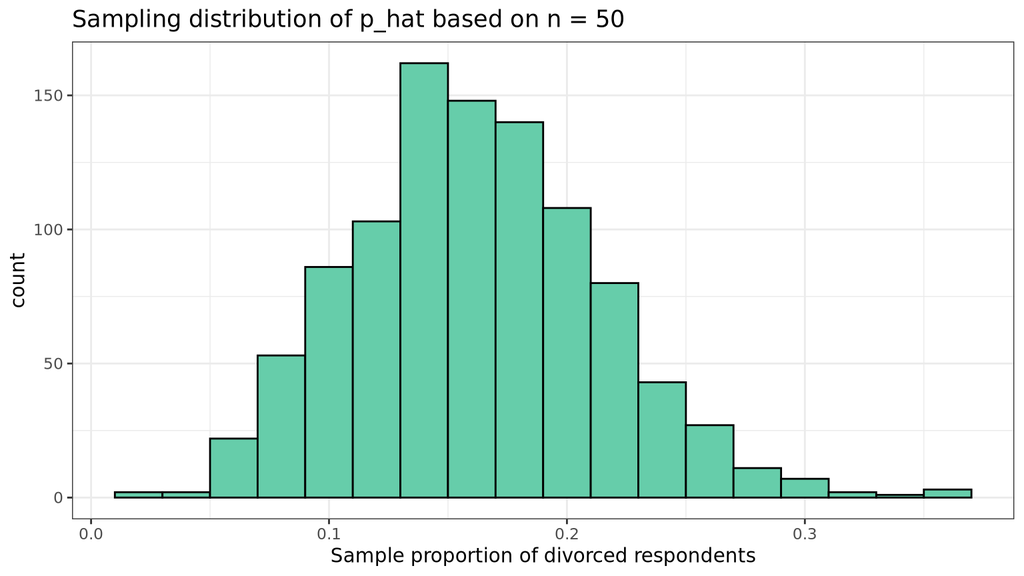

```r
ggplot(p_hat_n50_1000rep, aes(x = p_hat)) +
  geom_histogram(binwidth = 0.02, color = "black", fill = "aquamarine3") +
  labs(x = "Sample proportion of divorced respondents",
       title = "Sampling distribution of p_hat based on n = 50") +
  theme_bw()
```

5. Based on your histogram, what appeared to be a very common value of $\hat{p}$? What was a very uncommon value? Specifically, find the 1%, 99%, the mean, and the standard deviation of the values stored in `p_hat_n50` to help answer the question.

Type your complete sentence answer here using inline R code and delete this comment.

```r
# Your code here
```

## 5.3 Mean and Standard Error of the Sampling Distribution of $\hat{p}$ for $n = 50$

We can estimate the mean of the sampling distribution by calculating the mean of all 1000 $\hat{p}$ estimates, and the standard error of the sampling distribution by calculating the standard deviation of all 1000 $\hat{p}$ values as follows:

```r
p_hat_n50_1000rep %>%
  summarize(M_p_hat = mean(p_hat),
            SE_p_hat = sd(p_hat))
```

| M_p_hat | SE_p_hat |
| --- | --- |
| 0.16198 | 0.052215 |

6. How do these values compare to the estimates we got for $\hat{p}$ and $\widehat{SE}_{\hat{p}}$ for `Divorced` respondents based on your **single** sample of 50 people earlier in this Problem Set?

Type your complete sentence answer here using inline R code and delete this comment.

7. Use the `rep_sample_n` function to collect 1000 virtual samples of size $n = 15$. Store the 1000 virtual samples in an object named `n15_1000rep`. Use a seed of 910.

```r
# Type your code and comments inside the code chunk
```

8. Calculate sample proportion $\hat{p}$ of people who reported they were `Divorced` for each replicate of your $n = 15$ sampling. Store the results in `ques8` and display the first six rows of `ques8`.

```r
# Type your code and comments inside the code chunk
```

9. Visualize the sampling distribution of $\hat{p}$ from your $n = 15$ sampling with a purple histogram.

```r
# Type your code and comments inside the code chunk
```

10. Calculate the mean of the $n = 15$ sampling distribution, and the standard error of the $n = 15$ sampling distribution

```r
# Type your code and comments inside the code chunk
```

11. How does the standard error of the $n= 15$ sampling distribution compare to the standard error of the $n = 50$ sampling distribution?

Type your complete sentence answer here using inline R code and delete this comment.

12. Explain any observed differences from 11.

Type your complete sentence answer here using inline R code and delete this comment.

13. Use the `rep_sample_n` function to collect 1000 virtual samples of size $n = 600$. Store the 1000 virtual samples in an object named `n600_1000rep`. Use a seed of 84.

```r
# Type your code and comments inside the code chunk
```

14. Calculate the proportion $\hat{p}$ of people who reported they were `Divorced`for each replicate of your $n = 600$ sampling. Store the results in `ques14` and display the first six rows of `ques14`.

```r
# Type your code and comments inside the code chunk
```

15. Calculate the mean of the $n = 600$ sampling distribution, and the standard error of the $n = 600$ sampling distribution.

```r
# Type your code and comments inside the code chunk
```

16. Was there more **variability** from sample to sample when we took a sample size of 600 or a sample size of 50? **Explain what evidence you have for assessing this**.

Type your complete sentence answer here using inline R code and delete this comment.

17. Which sampling distribution looked more normally distributed (bell shaped and symmetrical); the one built on n = 15, 50 or 600? **Why?**

Type your complete sentence answer here using inline R code and delete this comment.

[figure not shown]

## 5.4 Estimating $\hat{p}$ and the Standard Error of $\hat{p}$ from a Single Sample (revisited)

In most instances, we do not have access to the full population as we did in this GSS data; instead we have to take a **sample** to try to say something about the **larger population**. Furthermore, in the real world, we typically only take a **single** sample from the population, due to time or money constraints.

So how do we **ESTIMATE** a $\hat{p}$ and a standard error of $\hat{p}$ when we only have a single sample, and not 1000 repeated samples? As demonstrated at the very beginning of the Problem Set we:

- estimate $\hat{p}$ from the sample
- use the formula for the standard error of $\hat{p}$ given in Equation (4.1) and repeated below to estimate SE based on a single sample

$$\widehat{SE}_{\hat{p}} \approx \sqrt{\frac{\hat{p} \times (1-\hat{p})}{n}}$$

18. Imagine we collected only a single small sample of 15 respondents as given from the code below.

```r
set.seed(53)
n15_1rep <- gss_14 %>%
  rep_sample_n(size = 15, reps = 1)
# and
n50_1rep <- gss_14 %>%
  rep_sample_n(size = 50, reps = 1)
```

Following the example from the beginning of the Problem Set (roughly line 138), estimate the **sample proportion** $\hat{p}$ of people who identified as `Divorced` based on `n15_1rep`… AS WELL AS the **standard error of $\hat{p}$**

```r
# Type your code and comments inside the code chunk
```

> You should have gotten a value reasonably close to the estimate we made earlier from our sampling distribution for $n = 15$! Note that when you must estimate a standard error from **only a single sample**, the formula **contains the sample size, n**. The larger the sample size n, the larger the number in the denominator of the SE formula.

Fill in the R Markdown table below with all the standard errors you computed for this problem set. In other words:

19. Replace `x` with the standard error you obtained by taking the standard deviation of the $n = 15$ sampling distribution Replace `a` with the standard error you obtained for a single sample of $n = 15$ using the mathematical formula.

When you are done, make sure all the `|` in the table still line up so your results print out in a table!

| Sample size n | SE via sd of sampling distribution | SE via one sample and formula |
| --- | --- | --- |
| 15 | x | a |
| 50 | y | b |

20. Based on what you observed for 19, **IF** you collected a single sample from 600 respondents, do you think the standard error will be smaller or larger than the one you calculated for $n = 15$. **Explain your reasoning**.

Type your complete sentence answer here using inline R code and delete this comment.